# Getting up and running with R Markdown

2022-01-27

For your assignments, copy and paste the YAML header from the class website (.rtf file) exactly at the top of your R Markdown document.

Remember to also include the setup chunk right below the YAML header, and load your libraries right after that.

```r
#Load libraries
library(tidyverse)
library(gapminder) #only for this example
```

We can write normal text here.

We can also make **bold** and *italic* script.

```r
#I can also write text as comments within a code chunk.
#The shortcut is cmd+alt+i (or ctrl+alt+i in windows).
```

Here is how numbering works.

# 1 Heading

## 1.1 Subheading

### 1.1.1 Sub-subheading

I can suppress default numbering, by adding “{-}”

## Suppressed numbering here.

We can execute code in a code chunk, like this:

```r
2+2
```

```
## [1] 4
```

We can do the same thing using inline code: two plus two equals 4.

Here is a code chunk, displaying a table and the code used to generate it.

```r
gapminder %>%
  head(5)
```

```
## # A tibble: 5 x 6
##   country     continent  year lifeExp      pop gdpPercap
##   <fct>       <fct>     <int>   <dbl>    <int>     <dbl>
## 1 Afghanistan Asia       1952    28.8  8425333      779.
## 2 Afghanistan Asia       1957    30.3  9240934      821.
## 3 Afghanistan Asia       1962    32.0 10267083      853.
## 4 Afghanistan Asia       1967    34.0 11537966      836.
## 5 Afghanistan Asia       1972    36.1 13079460      740.
```

Here is another code chunk, displaying a plot and the code used to generate it.

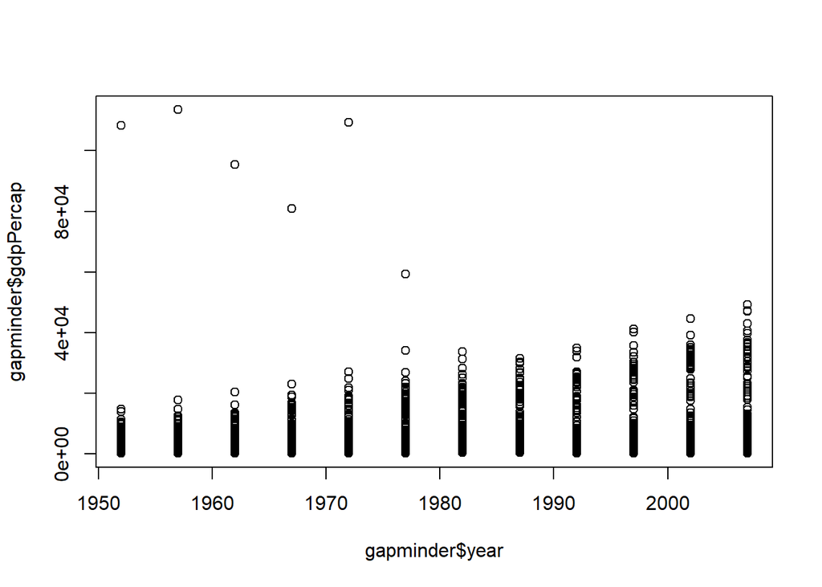

```r
plot(gapminder$year, gapminder$gdpPercap)
```

## Code chunk display options

In the setup chunk we set the global knit options to display **both code and results**, and suppress warnings and messages in our pdf output.

Usually, you will **not** have to change these settings when answering assignment questions.

- Use **{r}** for the default options

```r
table(gapminder$continent)
```

```
##
##   Africa Americas     Asia   Europe  Oceania
##      624      300      396      360       24
```

```r
#default display, inherited from the setup chunk.
#this is how to display answers for most assignment questions.
```

In very rare cases, we *can* change the display options within the code chunk. Suppose I only want to display results, and not code.

- Use **“{r echo = FALSE}”** in the chunk header to do this.

```
##
##   Africa Americas     Asia   Europe  Oceania
##      624      300      396      360       24
```

I can also display code, without results.

- Use **“{r results = ‘hide’}”** in the chunk header to do this.

```r
table(gapminder$continent)
```

## Additional tips

Don’t include “clunky” output that is not integral to answering the question.

As an example, consider the following question: *what is the mean GDP per capita of the gapminder dataset?*

The following is not a very good approach, since the output is clunky.

```r
summary(gapminder)
```

```
##         country        continent        year         lifeExp
##  Afghanistan:  12   Africa  :624   Min.   :1952   Min.   :23.60
##  Albania    :  12   Americas:300   1st Qu.:1966   1st Qu.:48.20
##  Algeria    :  12   Asia    :396   Median :1980   Median :60.71
##  Angola     :  12   Europe  :360   Mean   :1980   Mean   :59.47
##  Argentina  :  12   Oceania : 24   3rd Qu.:1993   3rd Qu.:70.85
##  Australia  :  12                  Max.   :2007   Max.   :82.60
##  (Other)    :1632
##       pop              gdpPercap
##  Min.   :6.001e+04   Min.   :   241.2
##  1st Qu.:2.794e+06   1st Qu.:  1202.1
##  Median :7.024e+06   Median :  3531.8
##  Mean   :2.960e+07   Mean   :  7215.3
##  3rd Qu.:1.959e+07   3rd Qu.:  9325.5
##  Max.   :1.319e+09   Max.   :113523.1
##
```

```r
#by inspection, 7215.3
```

The following is neater, but also not very good, since it still displays unecessary information, and the answer is “hard coded” - i.e. numbers are typed in - this is bad practice.

```r
summary(gapminder$gdpPercap)
```

```
##     Min.  1st Qu.   Median     Mean  3rd Qu.     Max.
##    241.2   1202.1   3531.8   7215.3   9325.5 113523.1
```

```r
#by inspection, 7215.3
```

The best way is to use inline code, as per below:

**The mean GDP in the gapminder dataset is 7215.3.** *(Note here that the number is generated using code, not typed out)*

## Some final remarks

- Do not hard code (i.e. do not type numeric values directly), instead, use inline code for simple calculations and code chunks for more complicated operations
- **Fill in code in your .R script first, and make sure everything works as intended. Only transfer your code to R Markdown when you are happy with your .R script.**

For more detail on R Markdown visit [Yihui Xie’s website](https://bookdown.org/yihui/rmarkdown/).